# Time Series: A First Course with Bootstrap Starter

# Lesson 12-6: Time Frequency Toggle Bootstrap

- We study a frequency domain sieve.

## Paradigm 12.6.1. Spectral Sieve

- The DFT $\widetilde{\underline{X}}$ is obtained from the sample $\underline{X}$ via multiplication by $Q$:
  $$\widetilde{\underline{X}} = Q^* \, \underline{X}.$$
- The DFT has asymptotic covariance given by diagonal matrix $\Lambda$; the diagonal entries are the spectral density evaluated at Fourier frequencies.
- So $\Lambda^{-1/2} \widetilde{\underline{X}}$ is asymptotically uncorrelated with common variance 1.
- Then
  $$\underline{\epsilon} = Q \, \Lambda^{-1/2} \, Q^* \, \underline{X}$$
  is an entropy-increasing transformation of the sample, and is an asymptotically uncorrelated sequence.
- We can base a bootstrap on $\underline{\epsilon}$; this is called a *spectral sieve*, because it involves an approximation to the true spectral density, which improves as the grid of Fourier frequencies becomes finer.
- To implement, we need an estimate of the spectral density.

## Example 12.6.3. Wolfer Sunspot Spectral Sieve

- Consider the Wolfer sunspot time series.
- We estimate the DFT.

```r
wolfer <- read.table("wolfer.dat")
wolfer <- ts(wolfer,start=1749,frequency=12)
n <- length(wolfer)
gamma.hat <- acf(wolfer,lag=n-1,type="covariance",plot=FALSE)$acf[,,1]

lambda <- seq(-floor(n/2)+1,floor(n/2))*2*pi/n
Q.mat <- exp(1i*seq(-floor(n/2)+1,floor(n/2)) %x% t(lambda))/sqrt(n)
wolfer.dft <- Conj(Q.mat) %*% (wolfer-mean(wolfer))
```

- We apply a tapered spectral estimator with Bartlett taper to estimate $f$.

```r
d <- 3*floor(n^{1/3})
wolfer.spec <- cos(0*lambda)*gamma.hat[1]
for(h in 1:(n-1))
{
    wolfer.spec <- wolfer.spec + 2*(max(1-h/d,0))*cos(h*lambda)*gamma.hat[h+1]
}
wolfer.spec <- ts(wolfer.spec,start=0,frequency=n)
```

- Then we construct the residuals, and check that they are a white noise.
- The decorrelation is imperfect, but is sufficiently low statistically.

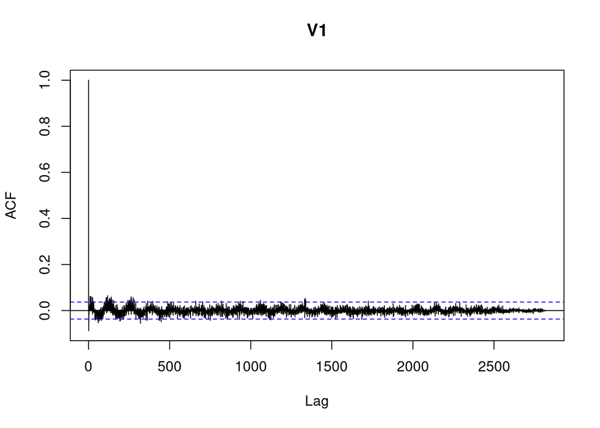

```r
wolfer.sieved <- wolfer.dft/sqrt(wolfer.spec)
wolfer.resids <- Re(Q.mat %*% wolfer.sieved)
gamma.resids <- acf(wolfer.resids,lag=n-1,type="correlation")$acf[,,1]
```

## Paradigm 12.6.8. Time Frequency Toggle Bootstrap

- We construct a bootstrap based on the spectral sieve.
- Let $\widehat{f}$ be a spectral density estimate, and $\widehat{\Lambda}$ is diagonal with entries given by evaluating at the Fourier frequencies.
- The *frequency domain residuals* are defined as $\widehat{\Lambda}^{-1/2} \widetilde{\underline{X}}$; these are asymptotically i.i.d. and Gaussian, by theory from Chapter 9.
- So we can generate bootstrap copies of the frequency domain residuals, transform to time domain by applying $Q$, and evaluate our statistic.
- This is called the *time frequency toggle* (TFT) bootstrap.

## Example 12.6.11. Lag 12 Autocorrelation of Gasoline Sales via TFT

- Consider the Gasoline sales time series data.
- We want to estimate the lag 12 autocorrelation, and measure the uncertainty using the TFT bootstrap.

```r
gassa <- read.table("GasSA_2-11-13.dat")
gassa <- ts(log(gassa),start=1992,frequency=12)
gas.diff <- diff(gassa)
n <- length(gas.diff)
gamma.hat <- acf(gas.diff,lag=n-1,type="covariance",plot=FALSE)$acf[,,1]
rho.hat <- acf(gas.diff,lag=n-1,type="correlation",plot=FALSE)$acf[,,1]
gas.acf12 <- rho.hat[13]
print(gas.acf12)
```

```
## [1] -0.239469
```

- We compute the DFT, and construct a spectral estimator based on a fitted AR(12).

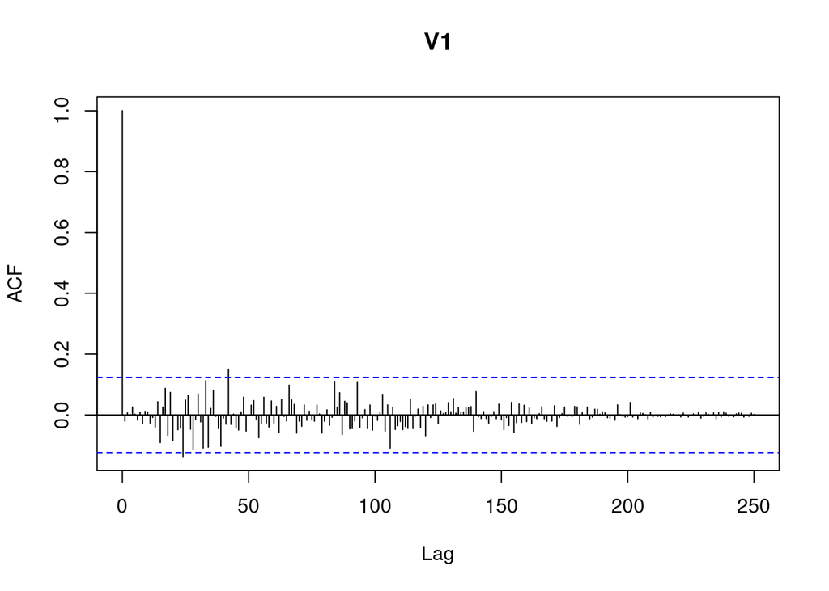

```r
lambda <- seq(-floor(n/2),floor(n/2))*2*pi/n
Q.mat <- exp(1i*seq(-floor(n/2),floor(n/2)) %x% t(lambda))/sqrt(n)
gas.dft <- Conj(Q.mat) %*% (gas.diff-mean(gas.diff))

p.order <- 12
phi.ar <- solve(toeplitz(gamma.hat[1:p.order])) %*% gamma.hat[2:(p.order+1)]
sig2.ar <- gamma.hat[1] - sum(phi.ar*gamma.hat[2:(p.order+1)])
gas.spec <- rep(1,n)
for(j in 1:p.order) { gas.spec <- gas.spec - phi.ar[j]*exp(-1i*j*lambda) }
gas.spec <- sig2.ar*Mod(gas.spec)^{-2}
gas.sieved <- gas.dft/sqrt(gas.spec)
#plot(ts(Re(gas.sieved)))
#ceps.sieve <- Q.mat %*% Lambda.mat %*% Conj(Q.mat)
gas.resids <- Re(Q.mat %*% gas.sieved)
gas.tft <- gas.sieved[1:(floor(n/2)+1)]
gamma.resids <- acf(gas.resids,lag=n-1,type="correlation")$acf[,,1]
```

- Next, we do the bootstrapping on the frequency domain residuals.

```r
gas.tft <- gas.tft - mean(gas.tft)
gas.edf.re <- sort(Re(gas.tft))
gas.edf.im <- sort(Im(gas.tft))

monte.roots <- NULL
Monte <- 100000
for(i in 1:Monte)
{
    monte.resids <- sample(gas.edf.re,size=(floor(n/2)+1),replace=TRUE) +
                1i*sample(gas.edf.im,size=(floor(n/2)+1),replace=TRUE)
    monte.resids[(floor(n/2)+1)] <- Re(monte.resids[(floor(n/2)+1)])
    monte.resids <- c(monte.resids,Conj(rev(monte.resids)[-1]))
    monte.sample <- Q.mat %*% monte.resids*sqrt(gas.spec)
    monte.sample <- Re(monte.sample)
    monte.root <- acf(monte.sample,lag=n-1,plot=FALSE,type="correlation")$acf[,,1][13] - gas.acf12
    monte.roots <- c(monte.roots,monte.root)
}
interval <- c(sort(monte.roots)[floor(.025*Monte)],sort(monte.roots)[floor(.975*Monte)])
```

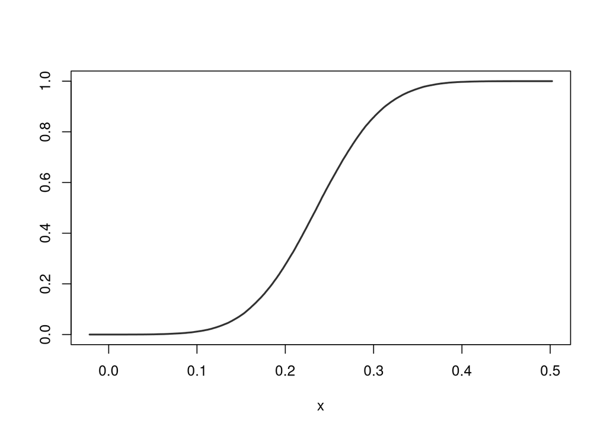

```r
plot(sort(monte.roots),seq(1,Monte)/Monte,type="l",xlab="x",ylab="",lwd=2,col=grey(.2))
```